# Regressão e romance

Hadrizia Santos

31 de julho de 2018

## Os dados

os dados descrevem 5000 encontros relâmpagos de 4 minutos envolvendo 310 jovens americanos. Os dados originais foram coletados por professores da Columbia Business School [no experimento descrito aqui](http://faculty.chicagobooth.edu/emir.kamenica/documents/genderDifferences.pdf). Os participantes tinham vários encontros de 4 minutos por noite. Após cada um, preenchiam fichas avaliando aqueles com quem se encontraram. Cada linha nos dados representa um desses encontros.

## A pergunta

O que causa atração à primeira vista? Ou seja, quais são as características mais e menos importantes para um homem/mulher ser percebido bem em um speed date?

```r
datings <- readr::read_csv(here::here("data/speed-dating.csv"),
                 progress = FALSE,
                 col_types =cols(int_corr = col_double(),
                                 field = col_character(),
                                 from = col_character(),
                                 career = col_character(),
                                 attr = col_double(),
                                 samerace = col_character(),
                                 sinc = col_double(),
                                 intel = col_double(),
                                 fun = col_double(),
                                 amb = col_double(),
                                 shar = col_double(),
                                 like = col_double(),
                                 prob = col_double(),
                                 match_es = col_double(),
                                 attr3_s = col_double(),
                                 sinc3_s = col_double(),
                                 intel3_s = col_double(),
                                 fun3_s = col_double(),
                                 amb3_s = col_double(),
                                 .default = col_integer()))  %>%
  mutate(from = as.numeric(factor(from)),
         gender = as.numeric(factor(gender)),
         samerace = as.numeric(factor(samerace)))
datings <- datings %>%
  select(iid, gender, order, pid, int_corr, samerace, age_o, age, field,
         race, from, career, sports, tvsports, exercise, dining, museums,
         art, hiking, gaming, clubbing, reading, tv, theater, movies,
         concerts, music, shopping, yoga, attr, sinc, intel, fun, amb,
         shar, like, prob, attr3_s, sinc3_s, intel3_s, fun3_s, amb3_s)

datings %>% glimpse()
```

[output not shown]

Os dados estão distribuídos nas seguintes colunas:

- `iid` : id do participante p1 no encontro
- `gender` : sexo do p1, 0 = mulher
- `order` : dos vários encontros realizados em uma noite, esse foi o n-ésimo, segundo essa variável
- `pid` : id do participante p2
- `int_corr` : correlação entre os interesses de p1 e p2
- `samerace` : p1 e p2 são da mesma raça?
- `age_o` : idade de p2
- `age` : idade de p1
- `field` : campo de estudo de p1
- `race` : raça de p1. O código é Black/African American=1; European/Caucasian-American=2; Latino/Hispanic American=3; Asian/Pacific Islander/Asian-American=4; Native American=5; Other=6
- `from` : de onde p1 é
- `career` : que carreira p1 quer seguir
- `sports`, `tvsports`, `exercise`, `dining`, `museums`, `art`, `hiking`, `gaming`, `clubbing`, `reading`, `tv`, `theater`, `movies`, `concerts`, `music`, `shopping`, `yoga` : De 1 a 10, quão interessado p1 é em cada uma dessas atividades.
- `attr` : quão atraente p1 achou p2
- `sinc` : quão sincero p1 achou p2
- `intel` : quão inteligente p1 achou p2
- `fun` : quão divertido p1 achou p2
- `amb` : quão ambicioso p1 achou p2
- `shar` : quanto p1 achou que compartilha interesses e hobbies com p2
- `like` : no geral, quanto p1 gostou de p2?
- `prob` : que probabiliade p1 acha que p2 tem de querer se encontrar novamente com p- (escala 1-10)
- `attr3_s` : quanto p1 acha que é atraente
- `sinc3_s` : quanto p1 acha que é sincero
- `intel3_s` : quanto p1 acha que é inteligente
- `fun3_s` : quanto p1 acha que é divertido
- `amb3_s` : quanto p1 acha que é ambicioso

#### Tratamento nos dados

Com uma pequena amostra dos dados, já percebe-se o quanto de dados faltosos exitem em algumas colunas. Essa falta pode ser melhor observada no gráfico abaixo:

[output not shown]

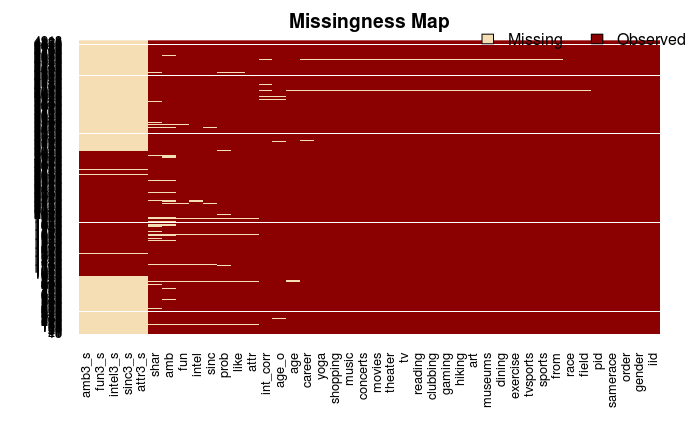

```r
missmap(datings)
```

As variáveis que possui mais dados faltosos são as váriaveis attr3_s, sinc3_s, intel3_s, fun3_s, amb3_s. Para lidar com isso, substituirei o dado faltando pela mediana da variável.

```r
f = function(x){
   x<-as.numeric(as.character(x))
   x[is.na(x)] = median(x, na.rm=TRUE)
   x
}
temp <- data.frame(apply(datings,2,f))
```

```
NAs introduzidos por coerçãoNAs introduzidos por coerção
```

```r
datings$attr3_s <- temp$attr3_s
datings$sinc3_s <- temp$sinc3_s
datings$intel3_s <- temp$intel3_s
datings$fun3_s <- temp$fun3_s
datings$amb3_s <- temp$amb3_s
```

Observando o resultado:

[output not shown]

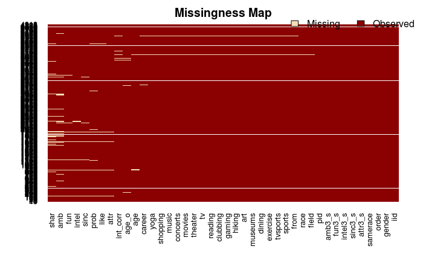

```r
missmap(datings)
```

Concluída a fase de processamento desses dados, agora é hora de criar um modelo.

#### Seleção das variáveis

```r
summary(like.model)
```

```
Call:
lm(formula = like ~ ., data = datings %>% select(-field, -career),
    na.action = na.omit)

Residuals:
    Min      1Q  Median      3Q     Max
-5.2247 -0.5611  0.0431  0.6034  6.8929

Coefficients:
              Estimate Std. Error t value Pr(>|t|)
(Intercept)  1.7921912  0.3530887   5.076 4.04e-07 ***
iid          0.0001684  0.0020101   0.084 0.933232
gender       0.0316202  0.0819885   0.386 0.699765
order        0.0001727  0.0030624   0.056 0.955037
pid         -0.0003543  0.0020098  -0.176 0.860062
int_corr     0.1075599  0.0597995   1.799 0.072146 .
samerace    -0.1051770  0.0362650  -2.900 0.003749 **
age_o       -0.0022296  0.0051438  -0.433 0.664709
age         -0.0193999  0.0058149  -3.336 0.000857 ***
race        -0.0491653  0.0150654  -3.263 0.001110 **
from         0.0002847  0.0003765   0.756 0.449566
sports      -0.0231562  0.0093566  -2.475 0.013371 *
tvsports     0.0066387  0.0077991   0.851 0.394707
exercise     0.0004972  0.0083705   0.059 0.952637
dining       0.0007252  0.0123042   0.059 0.953004
museums      0.0631864  0.0164902   3.832 0.000129 ***
art         -0.0480258  0.0147431  -3.258 0.001133 **
hiking       0.0040437  0.0076422   0.529 0.596745
gaming      -0.0074120  0.0079827  -0.929 0.353200
clubbing    -0.0106132  0.0077702  -1.366 0.172054
reading      0.0026862  0.0090708   0.296 0.767141
tv           0.0033803  0.0090753   0.372 0.709564
theater     -0.0018384  0.0105061  -0.175 0.861103
movies      -0.0316410  0.0130130  -2.431 0.015081 *
concerts     0.0326406  0.0117942   2.768 0.005675 **
music       -0.0343985  0.0125676  -2.737 0.006226 **
shopping    -0.0026024  0.0090799  -0.287 0.774421
yoga        -0.0085207  0.0069787  -1.221 0.222177
attr         0.3109385  0.0110470  28.147  < 2e-16 ***
sinc         0.0873873  0.0131401   6.650 3.32e-11 ***
intel        0.1270396  0.0163525   7.769 1.00e-14 ***
fun          0.1989655  0.0126346  15.748  < 2e-16 ***
amb         -0.0226521  0.0123563  -1.833 0.066842 .
shar         0.1951460  0.0107846  18.095  < 2e-16 ***
prob         0.1361146  0.0093540  14.551  < 2e-16 ***
attr3_s     -0.0888211  0.0219326  -4.050 5.23e-05 ***
sinc3_s      0.0305352  0.0202581   1.507 0.131811
intel3_s    -0.0317998  0.0263614  -1.206 0.227774
fun3_s      -0.0173233  0.0201980  -0.858 0.391126
amb3_s      -0.0041665  0.0189913  -0.219 0.826358
---
Signif. codes:  0 ‘***’ 0.001 ‘**’ 0.01 ‘*’ 0.05 ‘.’ 0.1 ‘ ’ 1

Residual standard error: 1.049 on 3953 degrees of freedom
  (925 observations deleted due to missingness)
Multiple R-squared:  0.6824,    Adjusted R-squared:  0.6792
F-statistic: 217.7 on 39 and 3953 DF,  p-value: < 2.2e-16
```

**Quais atributos causam atração à primeira vista?**